# ANOVA

If you want to compare means from two or more groups/populations, you can use the ANalysis Of VAriance (ANOVA). In R, this function is aov() and gives you a F-test value to show if there are differences between the means. If so, we can do mutliple comparison tests to figure out how they are different.

Say we have some simple data about weight loss from 3 drugs:

```r
weightLoss=c(2,5,4,0,1,7,8,8,6,9,3,1,7,4,5)
drug=c(rep("A",5),rep("B",5),rep("C",5))
weightData=data.frame(weightLoss, drug)
weightData
```

```
##    weightLoss drug
## 1           2    A
## 2           5    A
## 3           4    A
## 4           0    A
## 5           1    A
## 6           7    B
## 7           8    B
## 8           8    B
## 9           6    B
## 10          9    B
## 11          3    C
## 12          1    C
## 13          7    C
## 14          4    C
## 15          5    C
```

Let’s plot the data using a boxplot format: plot(response ~ factor, data=data_name)

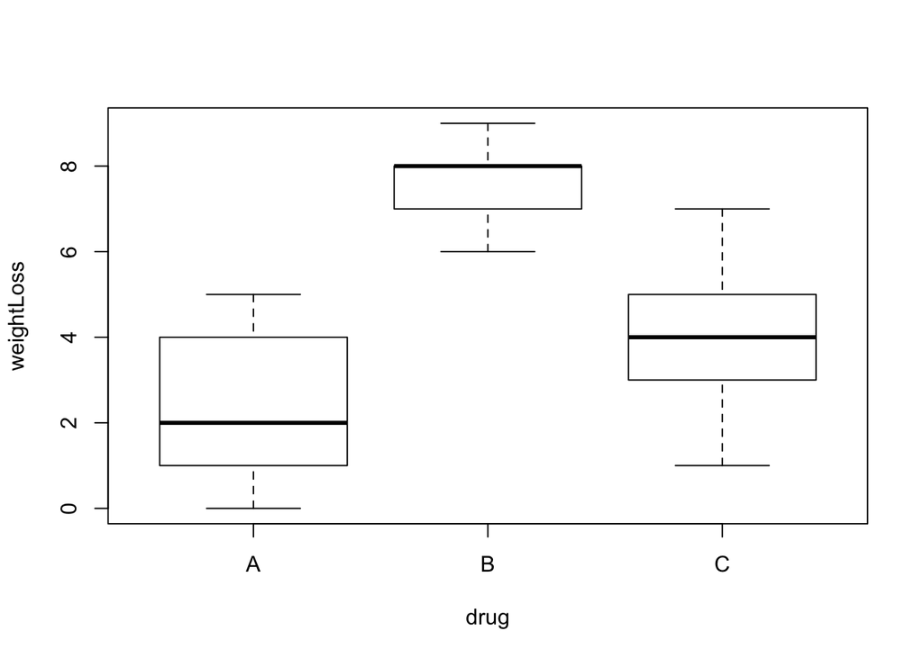

```r
plot(weightLoss ~ drug, data = weightData)
```

Looking at the plot, it seems that the mean for drug A is the lowest, B is the highest, and C is in the middle. What about the variance for each drug?

Let’s run the ANOVA now to look at differences in the means between the 3 groups.

We will use the formula:

aov(response ~ factor, data=data_name)  
–>seem familiar??

Then we can use the summary() function to see our ANOVA table.

```r
results=aov(weightLoss ~ drug, data=weightData)
summary(results)
```

```
##             Df Sum Sq Mean Sq F value  Pr(>F)
## drug         2  70.93   35.47   10.04 0.00274 **
## Residuals   12  42.40    3.53
## ---
## Signif. codes:  0 '***' 0.001 '**' 0.01 '*' 0.05 '.' 0.1 ' ' 1
```

From the table, we find our F value of 10.04 with a significance of 0.0027.

We can reject the hypothesis that all 3 drug means are equal.

Now what about figuring out how the means are different? We can now do multiple comparison tests. We’ll show you the pairwise t-test with Bonferroni correction and the Tukey method. Use the Bonferroni method when you are selecting which means to compare, and the Tukey method when comparing every mean to every other mean.

pairwise.t.test will perform pair-wise comparisons between group means, and we can correct for multiple comparisons with using the Bonferroni method:

pairwise.t.test(response, factor, p.adjust=method, alternative=c(“two.sided”,“less”,“greater”))

```r
pairwise.t.test(weightLoss, drug, p.adjust="bonferroni")
```

```
##
##  Pairwise comparisons using t tests with pooled SD
##
## data:  weightLoss and drug
##
##   A      B
## B 0.0027 -
## C 0.6097 0.0315
##
## P value adjustment method: bonferroni
```

From the output of this test, we can see the comparisons of the means between A&B and C&B are significantly different (p=0.0027, 0.0315, respectively) but the means between A&C are not significantly different (p=0.6097).

If you want to run a Tukey, use this formula:

TukeyHSD(x, conf.level=0.95)

where x is a fitted model object (like what we got from aov()).

```r
results=aov(weightLoss ~ drug, data=weightData)
TukeyHSD(results, conf.level=0.95)
```

```
##   Tukey multiple comparisons of means
##     95% family-wise confidence level
##
## Fit: aov(formula = weightLoss ~ drug, data = weightData)
##
## $drug
##     diff       lwr        upr     p adj
## B-A  5.2  2.028345  8.3716549 0.0024094
## C-A  1.6 -1.571655  4.7716549 0.3983052
## C-B -3.6 -6.771655 -0.4283451 0.0263588
```

This table shows us that the means between A&B and C&B are significantly different (p=0.0024, 0.026, respectively), but the means between A&C are not sig different (p=0.398). This confirms our Bonferroni test!